# Task13

## TASK 13.2

### Why is a Box-Cox transformation unhelpful for the cangas data?

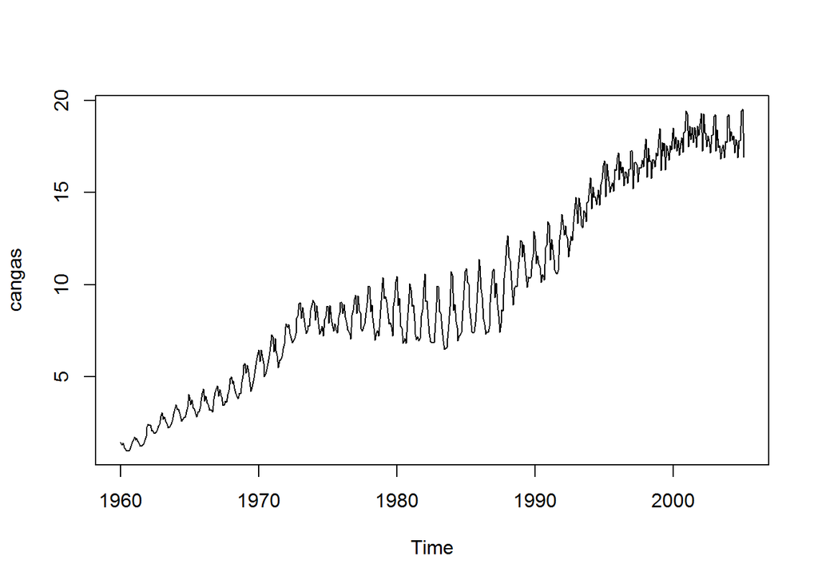

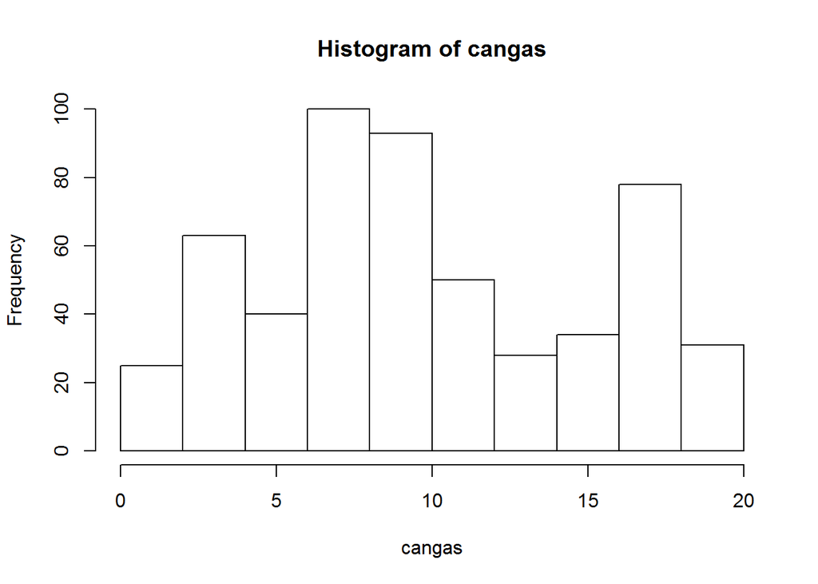

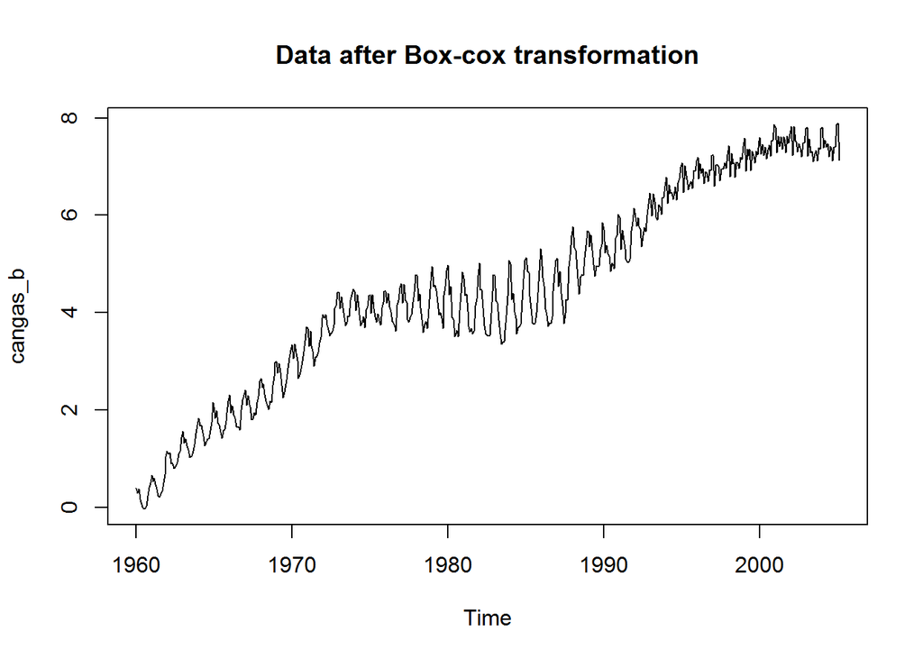

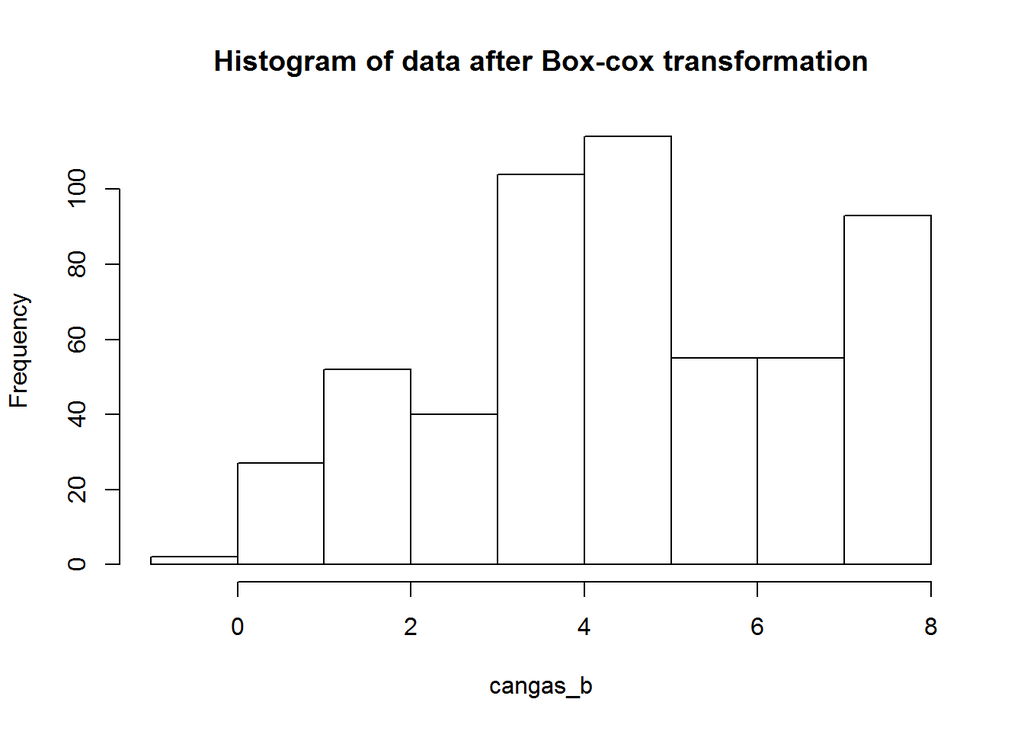

## TASK 13.3

### Download the data at http://robjhyndman.com/data/retail.xls. Choose one of the series and find an appropriate Box-Cox transformation and order of differencing in order to obtain stationary data.

At first, we have to read the data and transform it into time series.

```r
setwd(getwd())
dat<-read.csv2("retail.csv", sep = ";")
dat<-ts(dat, deltat = 1/12, start = c(1982, 4))
dat<-dat[,-1]
```

After doing so, we are ready to have a look at the data.

```
## [1] 303.1 297.8 298.0 307.9 299.2 305.4
```

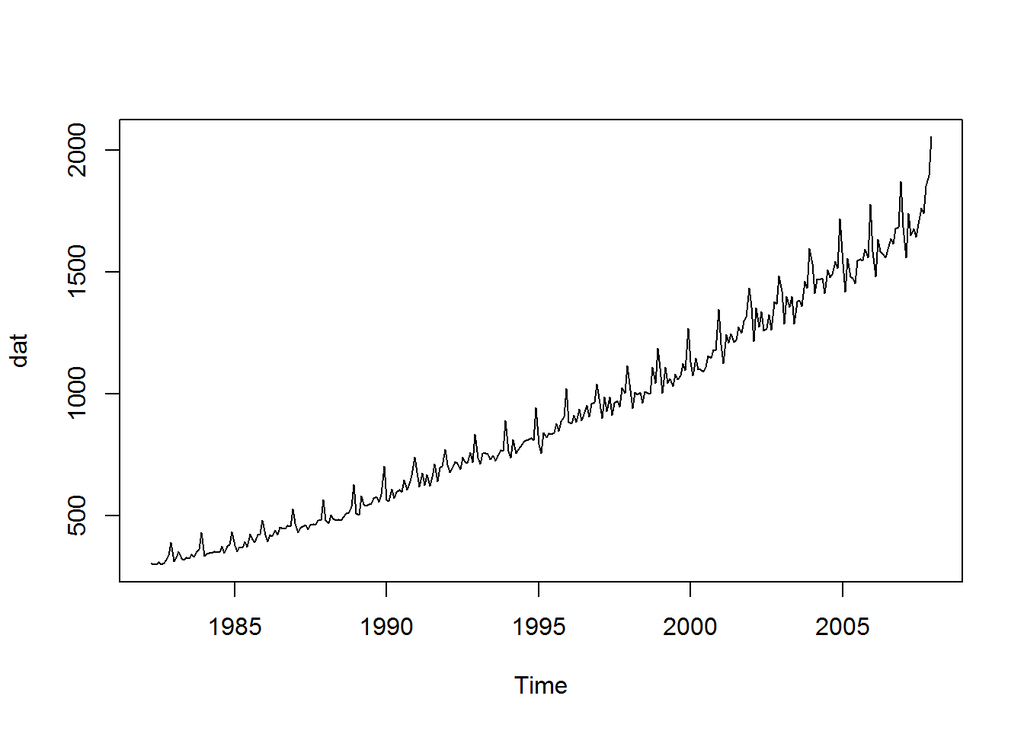

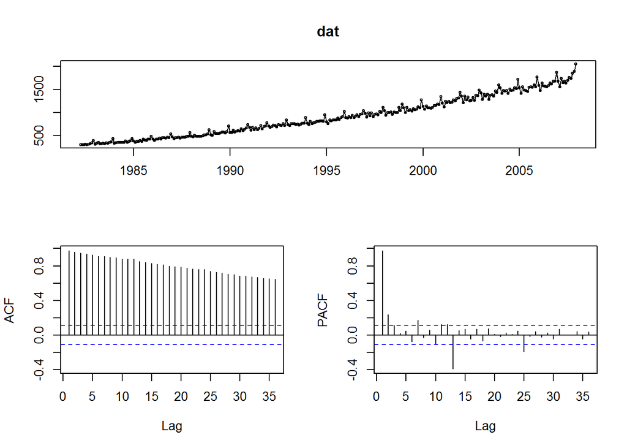

We have a monthly data of total turnover of industry in Victoria from April, 1982, to December, 2007. It is not stationary, so we have to use one of the techniques to make it stationary.

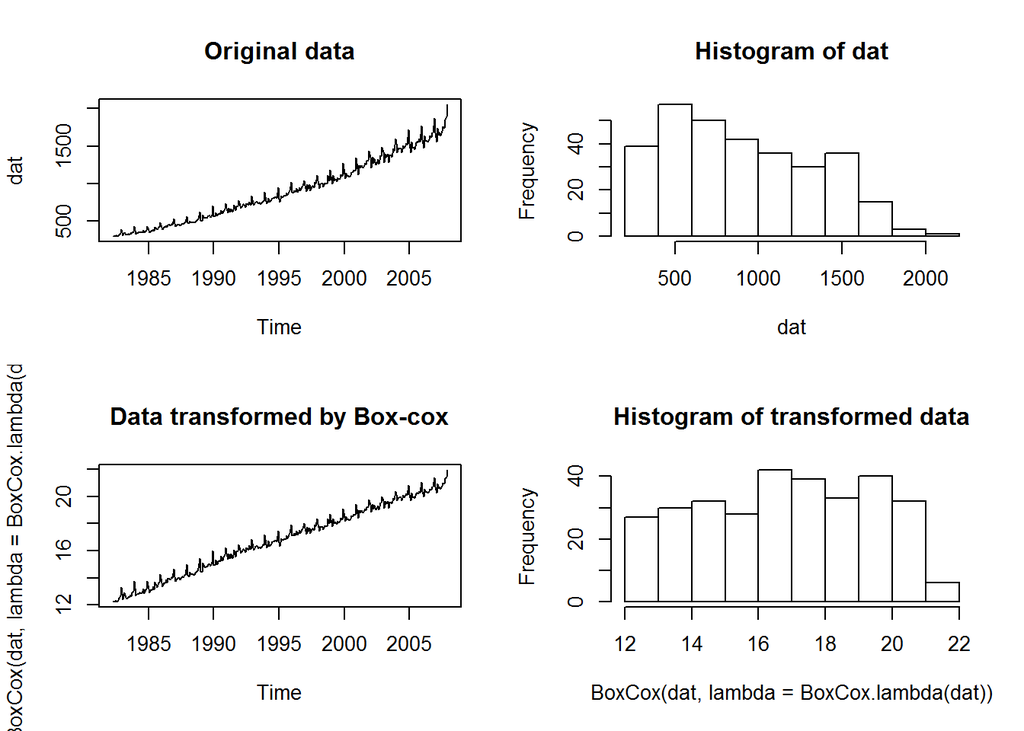

After Box-cox transformation, data is a little bit more regular.

```r
dat_d<-diff(dat, lag=frequency(dat), differences = nsdiffs(dat))
```

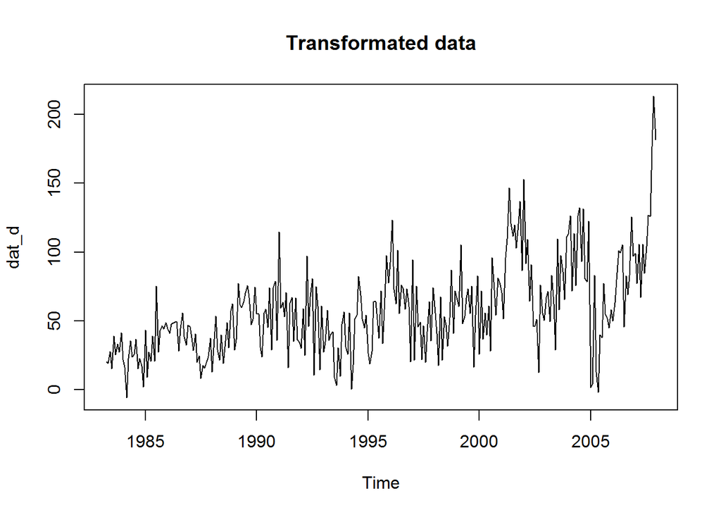

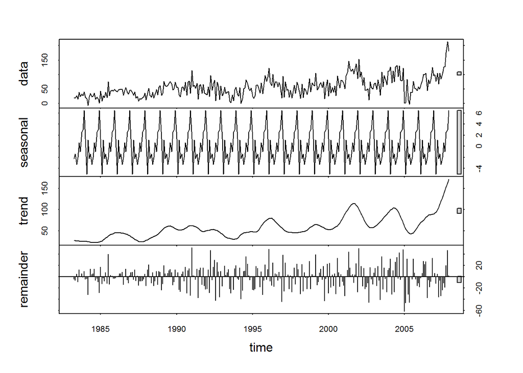